# Profit Optimization

Ensemble Models and Bayesian Workflow

Andrej Arpáš

12/15/2020

# Problem Setup

Imagine you’re optimizing (maximizing) for profit of some small business. The business has corporate clients (other corporate entities) and you have to decide which are to be targeted in a marketing campaign, the result of which should be a purchase decision on the part of the client. You target them by making a phone call but your call center can only handle calling 1/4 of the client base max. You have two datasets. One with the client base, and one called the pilot (which contains but a subset of the clients). Both contain 20 variables; the former requries making a recommendation (1 or 0) as to whom to target for the purchase, the latter also includes the purchase decisions and provides information about which clients, included in the pilot, were in the treatment group. Other than that, you know nothing about the variables.

One way to proceed is to use the pilot data as training and the client base data as the test set. Make inferences about which company to target and why. I’ll run a number of machine learning models, which, considering we know nothing about the variables, I don’t expect to perform all that well, comparing that approach to a simple Bayesian model in terms of their predictive accuracy and efficacy of making recommendations about which clients to target. The Bayesian model will give us a posterior to work with to gauge the probabilities with which a client would make a purchase decision, which is what we will optimize for.

Okay, what we can do, to start off with, is to run some models to figure out what the variables (vars) were that turned out predictive of a purchase decision based on the pilot.

The idea being that optimizing/maximizing for those vars that perform best would yield us the best candidates for modelling on the remainder of the customer base. (Provided that the sample in “pilot.csv” is representative and statistically sound otherwise, which is one assumption here. If so, we can use it to make inferences about the whole lot.)

## Data

A glance at what we’re dealing with.

```r
d <- read.csv("pilot.csv")

d %>% filter(treatment == 1) %>%
  head() %>% tibble() # Let's take a look.
```

```
# A tibble: 6 x 22
     V1 V2       V3    V4    V5    V6    V7    V8    V9   V10   V11    V12
  <dbl> <fct> <dbl> <dbl> <dbl> <dbl> <dbl> <dbl> <dbl> <dbl> <int>  <dbl>
1  0.76 A      0.11  0.44 36.7   0.28  47.0  0.38  1.67  5.5     18   27.8
2  1.09 A      0.42  0.16  2.04  0.37  36.7  0.49  0.7   9.27    10   31.4
3  0.69 A      0.24  0.87  6.02  0.3   44.0  0.56  2.39  9.47    19   48.2
4  0.98 A      0.62  0.93 31.2   1.83  44.8  0.81  4.51  8.1     19  704.
5  0.68 A      0.75  0.18 62.6   0.42  40.0  0.25  2.13  7.78    14   33.0
6  4.85 A      0.78  0.64 18.2   0.75  50.1  0.53  0.6  13.8     13 1730.
# … with 10 more variables: V13 <dbl>, V14 <dbl>, V15 <int>, V16 <dbl>,
#   V17 <dbl>, V18 <int>, V19 <fct>, V20 <dbl>, treatment <int>,
#   purchase <int>
```

```r
set.seed(42)

in_train <- createDataPartition(d$purchase, p = 0.8, list = FALSE)
training <- d[in_train, ]
testing <- d[-in_train, ]
```

## EDA

We can attempt some visualizations but since we don’t know what the vars represent, there isn’t much to discern patterns-wise.

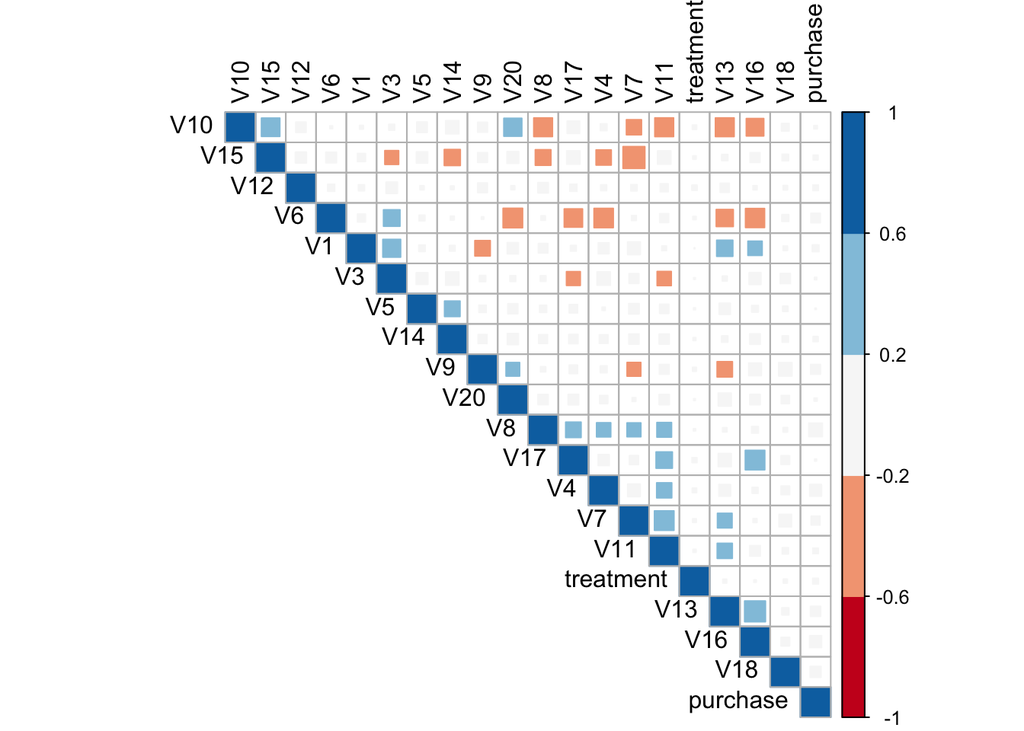

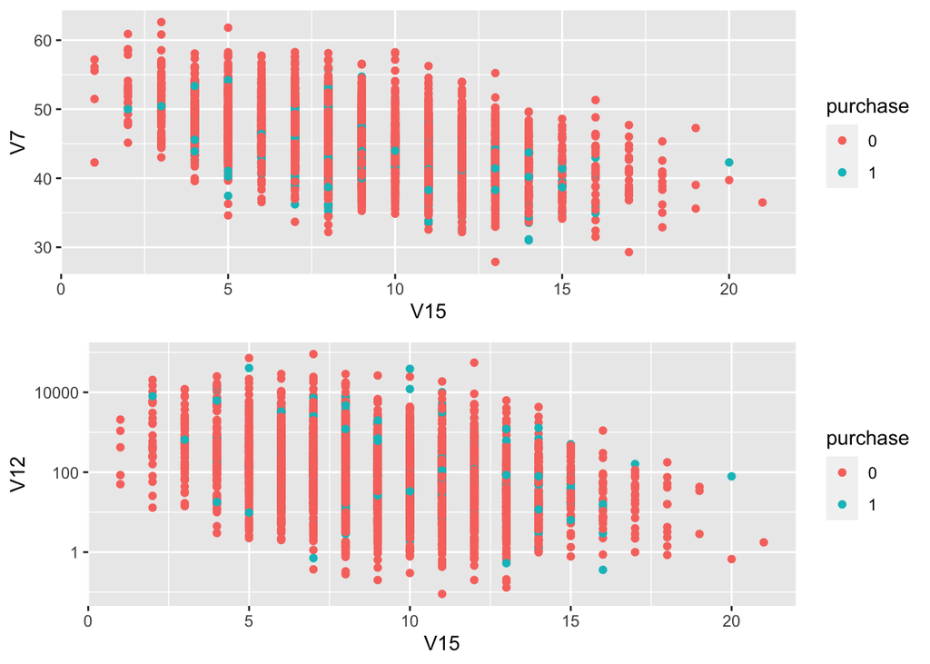

We may do at least one ensemble model, so let’s do some prep for that.

```r
ctrl <- trainControl(method = "cv", number = 10)
out <- train(as.factor(purchase) ~ ., data = training, method = "rpart2",
             tuneLength = 10, trControl = ctrl)
```

```
note: only 6 possible values of the max tree depth from the initial fit.
 Truncating the grid to 6 .
```

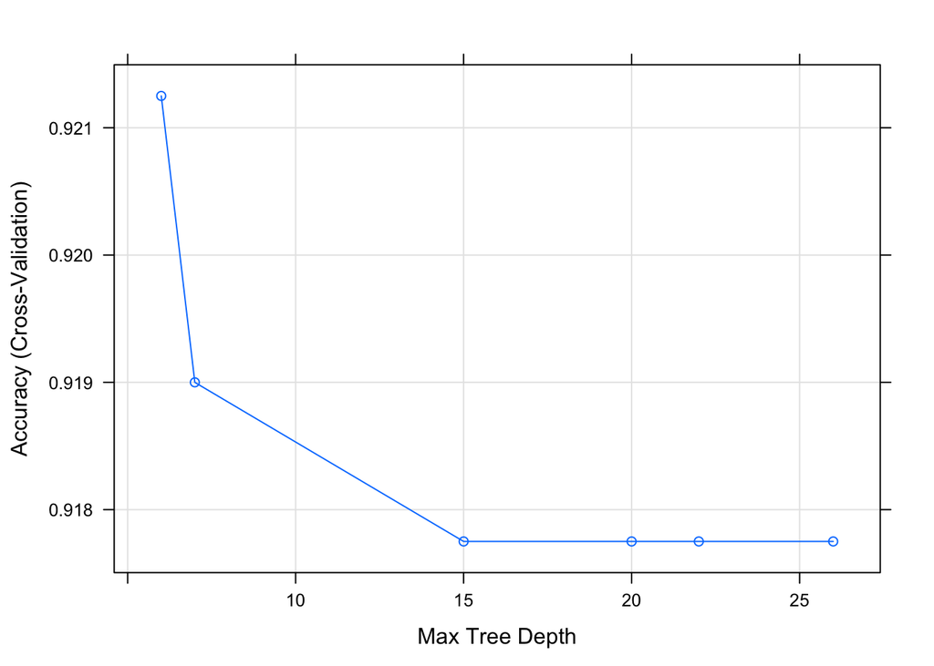

```r
plot(out)
```

So predictably, there are diminishing returns in using all vars. 15 max. should suffice but ideally way fewer.

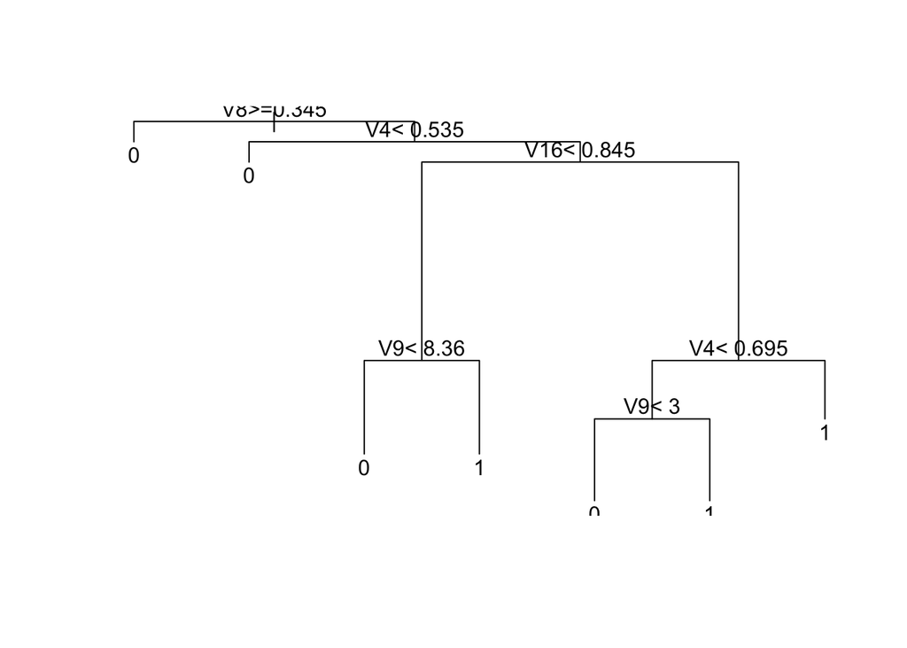

```r
plot(out$finalModel)
text(out$finalModel, pretty = 0)
```

```r
y_hat <- predict(out, newdata = testing)
defaultSummary(data.frame(obs = as.factor(testing$purchase),
                          pred = y_hat))
```

```
##  Accuracy     Kappa
## 0.9050000 0.1106867
```

Virtually guaranteed to overfit in the training data, and underperform on the test data, by default; these results, however, seem pretty good. Confirming the hypothesis is the fact that performing tree pruning to hone in on “the best” parts of the original tree simply returns the root, so this seems already the most optimal tree.

# Modelling

Let’s proceed to modelling and see if we can figure out what vars matter the most using some actual architectures. We can also do the modelling using `tidymodels` has a few extra wrinkels though, so let’s do the `train_test_split` the `tidymodels` way to avoid clashes.

```r
base_recipe <- recipe(buybool ~ ., data = purchase_train) %>% prep
tree_model <- decision_tree(mode = "classification", cost_complexity = 0.006) %>% set_engine("rpart") # cp = 0.01 as a default. Too high here.
tree_wflow <- workflow() %>% add_model(tree_model) %>%
  add_formula(buybool ~ V18 + V16 + V8 + V4) # Some weak correlations.
```

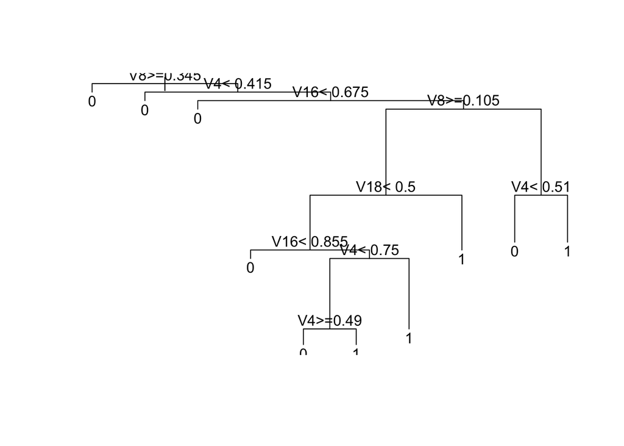

```r
tree_fit <- fit(tree_wflow, data = bake(base_recipe, NULL))

plot(tree_fit$fit$fit$fit)
text(tree_fit$fit$fit$fit, pretty = 0)
```

Get a confusion matrix implied by the model in the test set.

```r
bind_cols(purchase = purchase_test$buybool,
          predict(tree_fit,
                  new_data = bake(base_recipe, new_data = purchase_test))) %>%
  conf_mat(truth = purchase, estimate = .pred_class)
```

```
          Truth
Prediction    0    1
         0 1140   80
         1   20   10
```

Nothing to write home about in terms of predictiveness so far but let’s proceed somewhat cautiously.

## Random Forests (RF)

```r
best <- fit_rf %>% select_best("accuracy")
final <- finalize_workflow(rf_wflow, best)
rf_fit <- fit(final, data = bake(base_recipe, NULL))
bind_cols(purchase = purchase_test$buybool,
          predict(rf_fit,
                  new_data = bake(base_recipe, new_data = purchase_test))) %>%
  conf_mat(truth = purchase, estimate = .pred_class)
```

```
          Truth
Prediction    0    1
         0 1160   89
         1    0    1
```

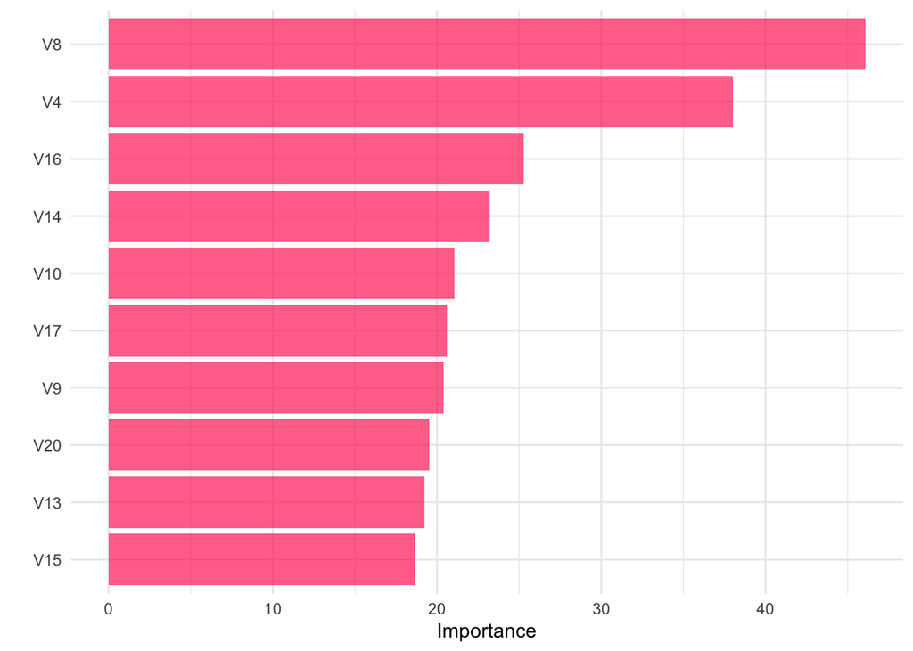

```r
vip::vip(rf_fit$fit$fit$fit, aesthetics = list(fill = "#FF3366", alpha = 0.7)) + theme_minimal()
```

The predictiveness is atrocious and the results confirm what the visualizations intimated all along, which is that these vars do not seem terribly predictive of the purchase deicison. Conditional on the model and the data, that is. Since we want an ensamble model, we grudgingly oblige but I’m not happy about this. That said, let’s do Boosting, and see if we can do better.

## Boosting

We still try to minimize the sum-of-squared residuals but in lieu of calculating the difference between the outcome and the strata-means, boosting calculates the difference between the residuals from earlier stages of the tree and the strata-means.

So far, we “got away with” factors/characters since `rpart`/`tidymodels` can handle that. For boosting, we need a sparse matrix. Let’s do a quick fix.

```r
f <- data.frame(lapply(e, function(x) as.numeric(x)))
f$buybool <- e$buybool

purchase_split_ <- initial_split(f, prob = 0.75, strata = buybool)
purchase_train_ <- training(purchase_split_)
purchase_test_ <- testing(purchase_split_)
boost_recipe <- recipe(buybool ~ ., data = purchase_train_) %>% prep
```

```r
boost_model <- boost_tree() %>%
  set_engine("xgboost", nthreads = parallel::detectCores()) %>%
  set_mode("classification")
boost_wflow <- workflow() %>% add_recipe(boost_recipe) %>% add_model(boost_model)

cv_ <- vfold_cv(bake(boost_recipe, NULL)) # 10-fold crosval.

fit_boost <- fit_resamples(boost_wflow, cv_,
                           control = control_resamples(verbose = FALSE,
                                                       save_pred = TRUE))
```

[output not shown]

```
          Truth
Prediction    0    1
         0 1123   88
         1   37    2
```

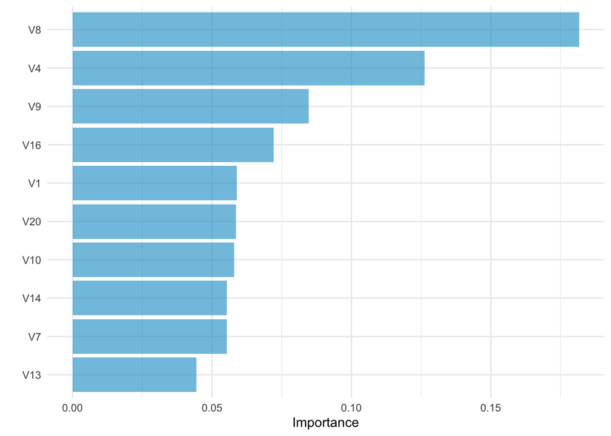

While this is technically an improvement the prediction is still pretty abysmal. That said, we can finally move on to more interesting models.

## Bayesian Additive Regression Trees (BART)

[output not shown]

[output cut: 20 more lines]

[output not shown]

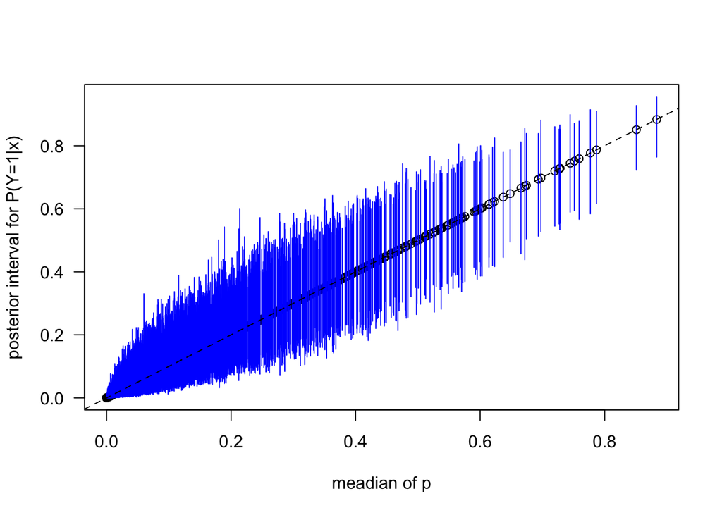

```r
bind_cols(purchase = as.factor(testing$purchase),
          .pred_class = factor(apply(out_bart$yhat.test, MARGIN = 3, FUN = mean) > 0.5,
                               levels = c(FALSE, TRUE), labels = 0:1)) %>%
  conf_mat(truth = purchase, estimate = .pred_class)
```

```
##           Truth
## Prediction   0   1
##          0 912  85
##          1   1   2
```

Doesn’t perform terrifically either. The trouble is that we have a lot of predictors and not a whole lot of observations. Nearest Shrunken Centroids (NSC) is a method that normally is quite well suited to such tasks. Let’s try that.

## Nearest Shrunken Centroids (NSC)

```r
ctrl_nsc <- trainControl(method = "repeatedcv", repeats = 3,
                         classProbs = TRUE, summaryFunction = twoClassSummary)
```

```r
NSC <- train(purchase ~ .,
             data = gpurchase_train, method = "pam", preProcess = c("center", "scale"),
             metric = "ROC", trControl = ctrl_nsc,
             tuneGrid = data.frame(.threshold = 0:25))
```

[output not shown]

```r
confusionMatrix(predict(NSC, newdata = gpurchase_test), reference = gpurchase_test$purchase)
```

```
Confusion Matrix and Statistics

          Reference
Prediction  yes   no
       yes    0    0
       no   117 1133

               Accuracy : 0.9064
                 95% CI : (0.8889, 0.922)
    No Information Rate : 0.9064
    P-Value [Acc > NIR] : 0.5246

                  Kappa : 0

 Mcnemar's Test P-Value : <2e-16

            Sensitivity : 0.0000
            Specificity : 1.0000
         Pos Pred Value :    NaN
         Neg Pred Value : 0.9064
             Prevalence : 0.0936
         Detection Rate : 0.0000
   Detection Prevalence : 0.0000
      Balanced Accuracy : 0.5000

       'Positive' Class : yes
```

It’s easy to predict well if one predicts that no one will buy the service; that’s also useless though. Let’s do something else. Why not try Discriminant Analysis (DA), e.g. linear DA or LDA and quadratic DA or QDA.

## Discriminant Analysis (DA)

### Linear Discriminant Analysis (LDA)

```r
LDA <- train(purchase ~ .,
             data = gpurchase_train, method = "lda", preProcess = c("center", "scale"))
confusionMatrix(predict(LDA, newdata = gpurchase_test), reference = gpurchase_test$purchase)
```

```
Confusion Matrix and Statistics

          Reference
Prediction  yes   no
       yes    8    7
       no   109 1126

               Accuracy : 0.9072
                 95% CI : (0.8897, 0.9227)
    No Information Rate : 0.9064
    P-Value [Acc > NIR] : 0.4859

                  Kappa : 0.1021

 Mcnemar's Test P-Value : <2e-16

            Sensitivity : 0.06838
            Specificity : 0.99382
         Pos Pred Value : 0.53333
         Neg Pred Value : 0.91174
             Prevalence : 0.09360
         Detection Rate : 0.00640
   Detection Prevalence : 0.01200
      Balanced Accuracy : 0.53110

       'Positive' Class : yes
```

### Quadratic Discriminant Analysis (QDA)

```r
QDA <- train(purchase ~ .,
             data = gpurchase_train, method = "qda", preProcess = c("center", "scale"))
confusionMatrix(predict(QDA, newdata = gpurchase_test), reference = gpurchase_test$purchase)
```

```
Confusion Matrix and Statistics

          Reference
Prediction  yes   no
       yes   36   90
       no    81 1043

               Accuracy : 0.8632
                 95% CI : (0.8429, 0.8818)
    No Information Rate : 0.9064
    P-Value [Acc > NIR] : 1.0000

                  Kappa : 0.2206

 Mcnemar's Test P-Value : 0.5407

            Sensitivity : 0.3077
            Specificity : 0.9206
         Pos Pred Value : 0.2857
         Neg Pred Value : 0.9279
             Prevalence : 0.0936
         Detection Rate : 0.0288
   Detection Prevalence : 0.1008
      Balanced Accuracy : 0.6141

       'Positive' Class : yes
```

These are the best results so far. There is significant sparseness in the dataset on account of ~8% purchase decisions only in the pilot. That doesn’t bode particularly well for models to learn on. Adding bells and whistles to fine-tune the QDA doesn’t shave off more false negatives. So we have our best performer.

# Back to Purchases

Let’s use the best model to predict purchases.

```r
h <- read.csv("CustomerBase.csv")
h <- subset(h, select = -c(V2, V18, V19)) # Use for predict.

g_ <- subset(g, select = -c(treatment))
```

## QDA Again

```r
QDA_ <- train(purchase ~ .,
              data = g_, method = "qda", preProcess = c("center", "scale"))
pred <- as.data.frame(predict(QDA_, newdata = h))
colnames(pred)[1] <- "pred"
h_pred <- cbind(h, pred)
h_pred$pred <- as.numeric(as.character(factor(h_pred$pred, labels = 1:0, levels = c("yes", "no"))))
```

Does this look reasonable? Shouldn’t have vastly more or less buys, as a fraction of the total, than we did in the pilot. It’s uncannily on target. Again, bear in mind that there are a lot of assumptions. We assume that the pilot was properly randomized and that the sampling was representative of the lot. We further condition on the model and the rest of the data. This also tells us that the model didn’t learn all that much on the training data (pilot).

```r
d %>% group_by(purchase) %>% summarize(n = n()) %>% mutate(buys = n / sum(n))
```

```
## # A tibble: 2 x 3
##   purchase     n   buys
##      <int> <int>  <dbl>
## 1        0  4583 0.917
## 2        1   417 0.0834
```

```r
h_pred %>% group_by(pred) %>% summarize(n = n()) %>% mutate(buys = n / sum(n))
```

```
## # A tibble: 2 x 3
##    pred     n   buys
##   <dbl> <int>  <dbl>
## 1     0 87141 0.917
## 2     1  7859 0.0827
```

Seeing the model expects only 7,859 purchases and our call center capacity is 1/4 of the client base (23,750), we can call all our targets and will still have a buffer. Now, provided that we have already paid for the capacity/bandwidth, we might as well use it, though this is a speculation, in which case we could lower the probabilty threshold for the model from .5 to something smaller, which isn’t advisable if we can avoid it, which in most cases we can. Should we have the opposite, i.e. more candidates than spots/capacity in the call center, we could do `stan_clogit` to yield a posterior with probabilities for who is the most likely to purchase and call them in the order of the likelihood. Honestly, our output suggests that machine learning (ML) doesn’t really promote thinking. It’s useful, but what you really want is to understand your variables, do some proper modelling, ideally Bayesian, and perform statistical data analysis on your variables to prune them and in order to make hypotheses. You can in fact do everything purely Bayesian and have better predictions. Which is exactly what I’m going to show you next. We know nothing about our variables though, so it won’t be as effective as it should but my guess is that it will still predict better than ML. Okay, so next up, Bayes.

## `stan_glm`

One of the simpler models that is well suited to classification tasks though.

```r
options(mc.cores = parallel::detectCores())
set.seed(42)
```

Let’s look at those correlations once more and we’re off to the races.

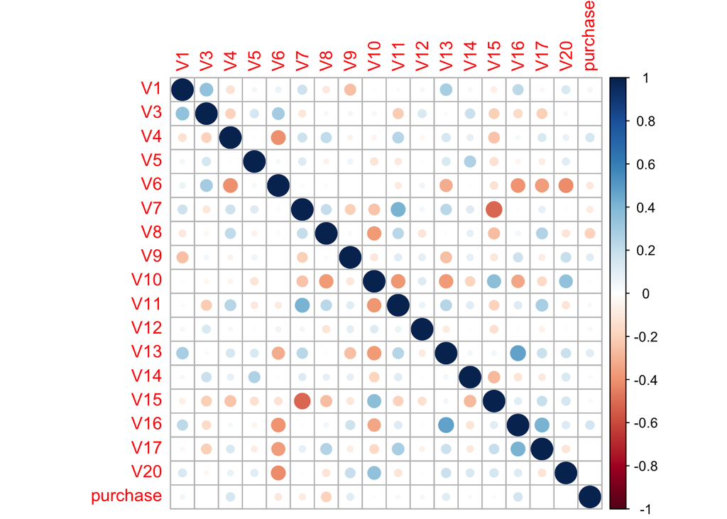

```r
df <- subset(g, select = -c(treatment)) # Drop non-numeric, zero variance vars.
df$purchase <- as.numeric(as.character(factor(df$purchase, labels = 1:0, levels = c("yes", "no"))))
corrplot(cor(df))
```

```r
x <- model.matrix(purchase ~ . - 1, data = df) # -1 meaning all but "y".
y <- df$purchase

# Degrees of freedom (`df`) in `student_t` are 1 as a default, which is identical to `cauchy`, so just move that. Default otherwise.
t_prior <- student_t(df = 2, location = 0, scale = 2.5) # Uninformative prior.
fit <- stan_glm(purchase ~ ., data = df,
                family = binomial(link = "logit"),
                prior = t_prior, prior_intercept = t_prior,
                QR = TRUE) # Recommended for computational reasons when there are multiple predictors.
```

```r
round(posterior_interval(fit, prob = 0.9), 2)
```

```
               5%   95%
(Intercept) -2.32  1.18
V1           0.07  0.19
V3           0.22  1.07
V4           2.96  3.88
V5           0.00  0.00
V6          -0.20  0.02
V7          -0.11 -0.05
V8          -4.26 -3.32
V9           0.12  0.22
V10         -0.07  0.03
V11          0.01  0.08
V12          0.00  0.00
V13          0.29  1.36
V14         -0.01  0.00
V15         -0.05  0.05
V16          1.05  2.10
V17         -0.13  0.00
V20         -0.08 -0.03
```

```r
summary(fit, pars = c("V1", "V3", "V4", "V5", "V6",
                      "V7", "V8", "V9", "V10", "V11",
                      "V12", "V13", "V14", "V15", "V16",
                      "V17", "V20"))
```

```
Model Info:
 function:     stan_glm
 family:       binomial [logit]
 formula:      purchase ~ .
 algorithm:    sampling
 sample:       4000 (posterior sample size)
 priors:       see help('prior_summary')
 observations: 5000
 predictors:   18

Estimates:
      mean   sd   10%   50%   90%
V1   0.1    0.0  0.1   0.1   0.2
V3   0.6    0.3  0.3   0.6   1.0
V4   3.4    0.3  3.1   3.4   3.8
V5   0.0    0.0  0.0   0.0   0.0
V6  -0.1    0.1 -0.2  -0.1   0.0
V7  -0.1    0.0 -0.1  -0.1  -0.1
V8  -3.8    0.3 -4.2  -3.8  -3.4
V9   0.2    0.0  0.1   0.2   0.2
V10  0.0    0.0 -0.1   0.0   0.0
V11  0.0    0.0  0.0   0.0   0.1
V12  0.0    0.0  0.0   0.0   0.0
V13  0.8    0.3  0.4   0.8   1.2
V14  0.0    0.0  0.0   0.0   0.0
V15  0.0    0.0  0.0   0.0   0.0
V16  1.6    0.3  1.2   1.6   2.0
V17 -0.1    0.0 -0.1  -0.1   0.0
V20 -0.1    0.0 -0.1  -0.1   0.0

MCMC diagnostics
    mcse Rhat n_eff
V1  0.0  1.0  8602
V3  0.0  1.0  6954
V4  0.0  1.0  5764
V5  0.0  1.0  4097
V6  0.0  1.0  6632
V7  0.0  1.0  7010
V8  0.0  1.0  4984
V9  0.0  1.0  6642
V10 0.0  1.0  6434
V11 0.0  1.0  7833
V12 0.0  1.0  5910
V13 0.0  1.0  6592
V14 0.0  1.0  4586
V15 0.0  1.0  7630
V16 0.0  1.0  6527
V17 0.0  1.0  6447
V20 0.0  1.0  6177

For each parameter, mcse is Monte Carlo standard error, n_eff is a crude measure of effective sample size, and Rhat is the potential scale reduction factor on split chains (at convergence Rhat=1).
```

### Diagnostics

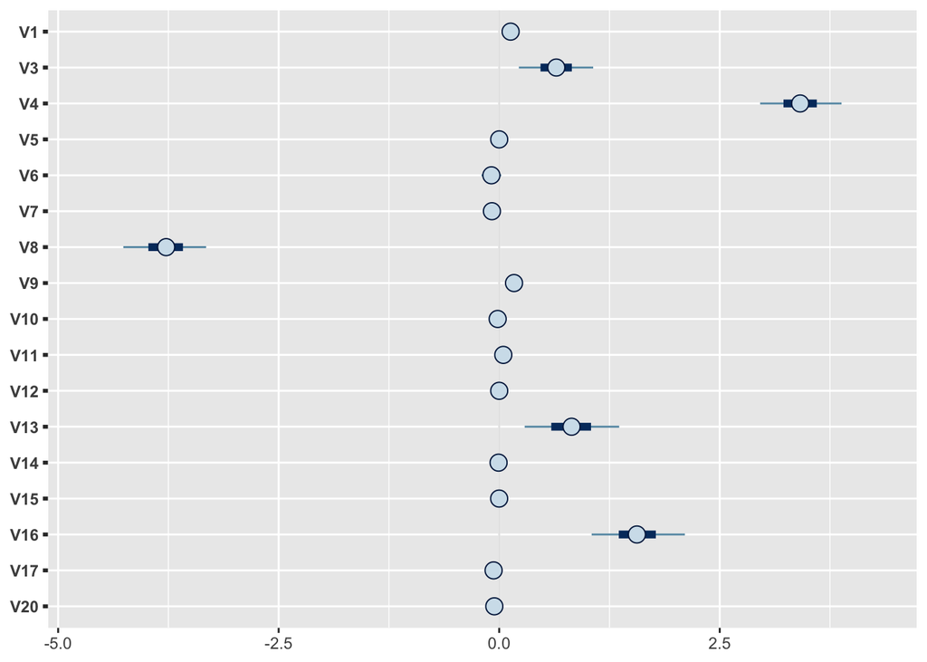

```r
plot(fit, pars = c("V1", "V3", "V4", "V5", "V6",
                   "V7", "V8", "V9", "V10", "V11",
                   "V12", "V13", "V14", "V15", "V16",
                   "V17", "V20"))
```

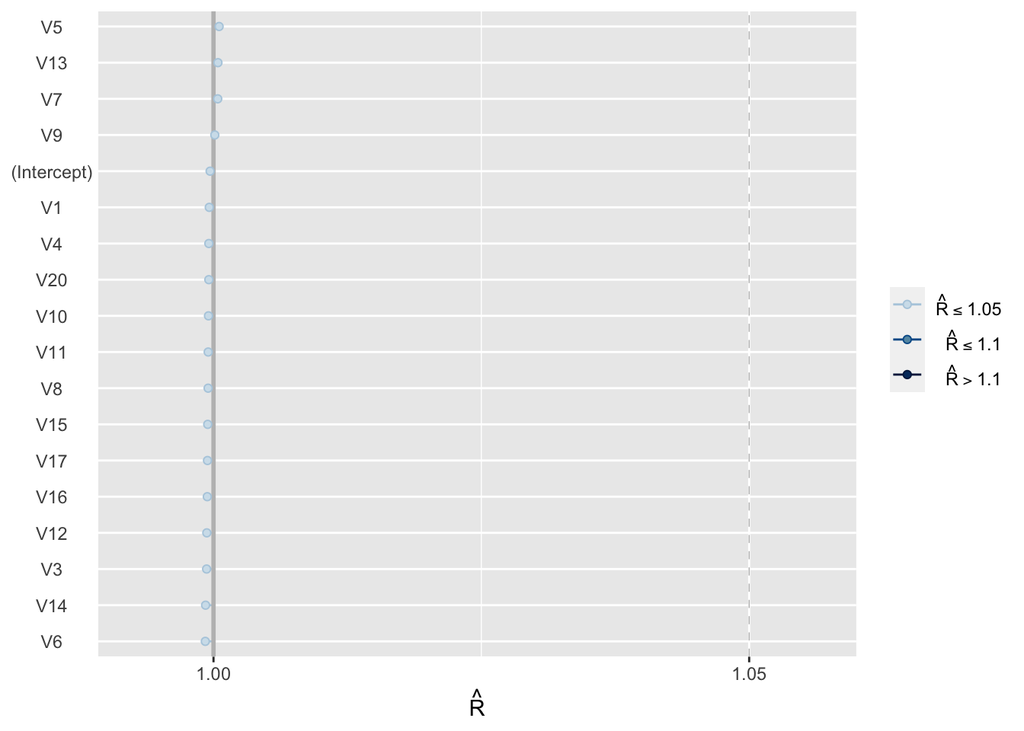

```r
fit %>% rhat() %>% mcmc_rhat() + yaxis_text()
```

We can note that `R_hat` is close to 1 (<1.01), meaning the four Markov chains are in close agreement with one another. So this looks good.

```r
# Pareto smoothed leave-one-out crosval (PSIS-LOO).
loo(fit, save_psis = TRUE, k_threshold = 0.7)
```

```
2 problematic observation(s) found.
Model will be refit 2 times.
```

```
Fitting model 1 out of 2 (leaving out observation 1483)
```

```
Fitting model 2 out of 2 (leaving out observation 3158)
```

```
Computed from 4000 by 5000 log-likelihood matrix

         Estimate   SE
elpd_loo  -1111.0 40.4
p_loo        19.2  1.5
looic      2221.9 80.7
------
Monte Carlo SE of elpd_loo is 0.1.

Pareto k diagnostic values:
                         Count Pct.    Min. n_eff
(-Inf, 0.5]   (good)     4997  100.0%  2373
 (0.5, 0.7]   (ok)          1    0.0%  1043
   (0.7, 1]   (bad)         0    0.0%  <NA>
   (1, Inf)   (very bad)    0    0.0%  <NA>

All Pareto k estimates are ok (k < 0.7).
See help('pareto-k-diagnostic') for details.
```

PSIS-LOO result seems reliable enough with all Pareto k estimates less than 0.7.

```r
linpred <- posterior_linpred(fit)
preds_ <- posterior_linpred(fit, transform = TRUE)
pred_ <- colMeans(preds_)
pr <- as.integer(pred_ >= 0.5)

round(mean(xor(pr, as.integer(y==0))), 2) # Accuracy.
```

```
## [1] 0.92
```

```r
truth <- df$purchase

u_ <- union(pr, truth)
t_ <- table(factor(pr, u_), factor(truth, u_),
            dnn = c("pr", "truth"))

colnames(t_) <- c("no", "yes")
rownames(t_) <- c("no", "yes")

caret::confusionMatrix(t_)
```

```
## Confusion Matrix and Statistics
##
##      truth
## pr      no  yes
##   no  4556  357
##   yes   27   60
##
##                Accuracy : 0.9232
##                  95% CI : (0.9155, 0.9304)
##     No Information Rate : 0.9166
##     P-Value [Acc > NIR] : 0.04692
##
##                   Kappa : 0.2155
##
##  Mcnemar's Test P-Value : < 2e-16
##
##             Sensitivity : 0.9941
##             Specificity : 0.1439
##          Pos Pred Value : 0.9273
##          Neg Pred Value : 0.6897
##              Prevalence : 0.9166
##          Detection Rate : 0.9112
##    Detection Prevalence : 0.9826
##       Balanced Accuracy : 0.5690
##
##        'Positive' Class : no
##
```

```r
ytilde <- posterior_predict(fit, newdata = h, draws = 1000)
dim(ytilde)
```

```
[1]  1000 95000
```

```r
pr2 <- colMeans(ytilde)
pr3 <- ifelse(pr2 >.5, 1, 0)
sum(pr3) # ~15 hundred purchases only.
```

```
[1] 1555
```

So, if we want to do this “old school”, and specify a .5 probability threshold, we generate a binary outcome, purchase / no purchase, but that doesn’t necessarily make a whole lot of sense. Furthermore, doing so gives us merely around 15 hundred “buys”, whereas what we ideally want is to identify up to 23,750 targets for our marketing campaign that would generate those purchases. Indeed, we do Bayes because we want to avail ourselves of the power of posterior distributions and the probabilistic nature of the models. Therefore, what I suggest is to look at the means of the probabilities from 1,000 draws from the posterior distribution, order them from highest to smallest, and identify 23,750 of the highest ones in descending order.

```r
dec <- as.data.frame(pr2) # Decisions.
dec_ <- dec %>% arrange(desc(pr2)) #%>% head(n = 15)
dec_$company_name <- rownames(dec_)
rownames(dec_) <- NULL
dec_$pr2[1:23750] <- 1
dec_$pr2[23751:nrow(dec_)] <- 0
```

```r
pr_final <- dec %>% arrange(desc(pr2))
dec_$prob <- pr_final$pr2
colnames(dec_)[1] <- c("decision")
colnames(dec_)
```

```
## [1] "decision"     "company_name" "prob"
```

```r
dec_final <- dec_ %>% arrange(as.numeric(as.character(company_name)))
dec_final %>% head(n = 15) %>% tibble()
```

```
## # A tibble: 15 x 3
##    decision company_name  prob
##       <dbl> <chr>        <dbl>
##  1        0 1            0.021
##  2        0 2            0.009
##  3        0 3            0.008
##  4        1 4            0.304
##  5        0 5            0.016
##  6        1 6            0.096
##  7        1 7            0.101
##  8        1 8            0.145
##  9        0 9            0.01
## 10        1 10           0.637
## 11        0 11           0.036
## 12        1 12           0.097
## 13        0 13           0.005
## 14        1 14           0.286
## 15        0 15           0.008
```

# Conclusion and Final Output

What we have is a data frame / Excel document with the clients ordered the way expected, with the recommended decision and probability with which that client will make a purchase adjacent, conditional on the data and the model. This is a much better approach, in my estimation, than regular ML.